# To Bank or Not to Bank: Portuguese Bank Marketing Data Analysis

December 20, 2018

## Agenda

- Dataset Overview
- Significant Data Visualization
- Replacing Missing Variables
- Encodeing/Recoding Options
- Disscussion of Possible Models
- Optimal Model: No Hyperparameters
- Optimal Model: Hyperparameters Selected
- Conclusions

## Dataset Overview

- Marketing data from Portuguese banking institution
- 1 DV: whether or not the potential customer made a term deposit after the campaign
- 16 IVs: 7 numeric, 9 categorical

## Relevenace of Analysis

- Important from both cost and operational effectiveness perspectives
  - Cost: minimize labor costs, refine lending practices
  - Operations: provide appropriate level of service, know who to do business with in the future

## Visualization: Distribution of Target

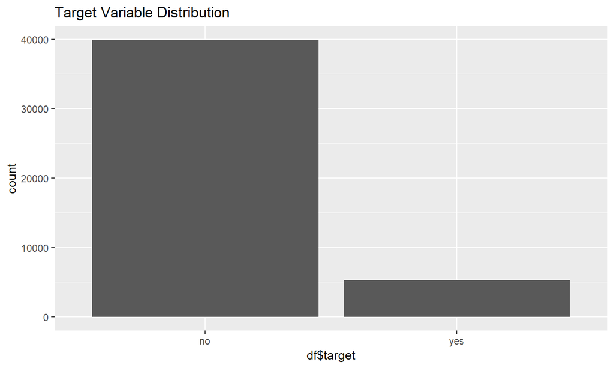

## Visualization: Average Contact Duration by Campaign Success

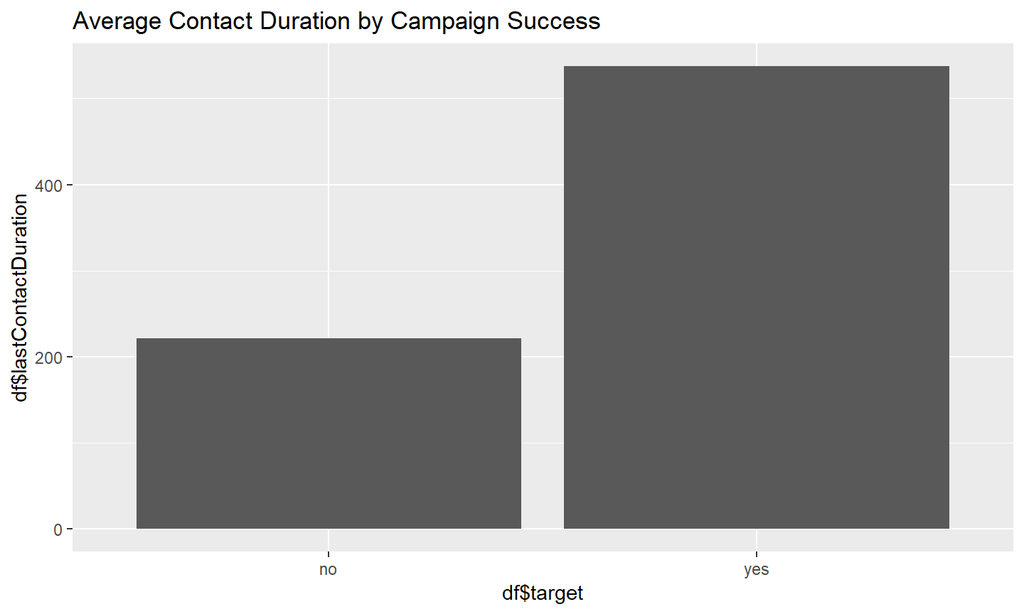

## Visualization: Average Credit Balance By Default Status

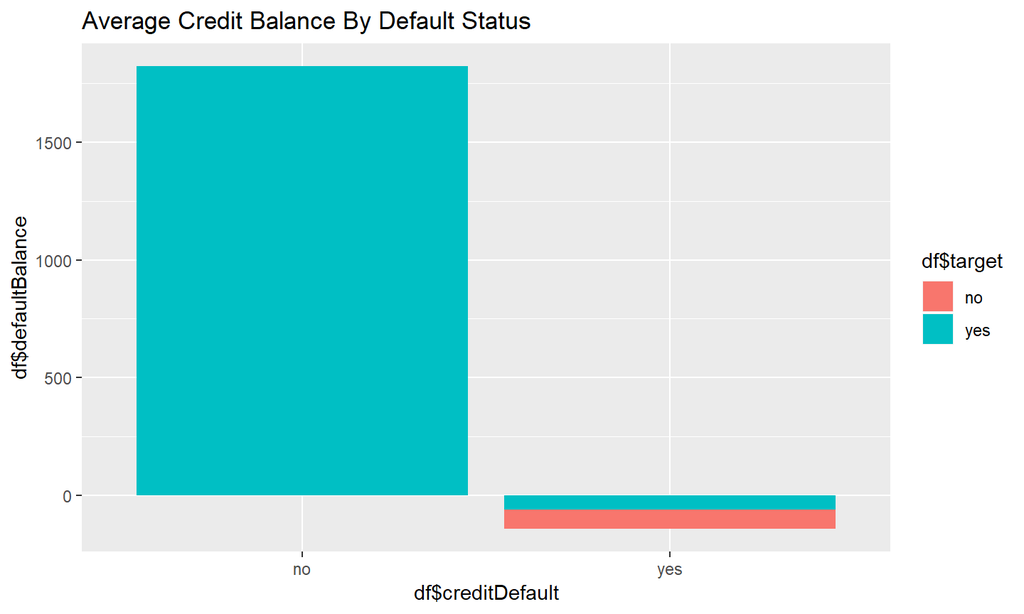

## Replacement Methods

- Create missing at random (original data complete)
  - df <- as.data.frame(lapply(df, function(cc) cc[ sample(c(TRUE, NA), prob = c(0.95, 0.05), size = length(cc), replace = TRUE) ]))
- Impute by mean
  - repnum = function(x){ for(i in 1:ncol(x)){ if(is.numeric(x[,i])){ x[is.na(x[,i]), i] <- mean(x[,i], na.rm = TRUE) } } return(x) } df = repnum(df)
- Impute by mode
  - repcat = function(x){ for(i in 1:ncol(x)){ if(is.factor(x[,i])){ x[,i][is.na(x[,i])] = levels(x[,i])[which.max(table(x[,i]))] } } return(x) } df = repcat(df)
- Remove rows with missing variables
  - df = df[complete.cases(df), ]

## Recoding Options

- Recoding 1: converting the job descriptions into four categories
  - levels(df$jobClass) <- c("whiteCollar", "blueCollar", "whiteCollar", "blueCollar", "whiteCollar", "Other", "Mixed", "Mixed", "Other", "blueCollar", "Other", "Other")
- Recoding 2: months into seasons
  - levels(df$lastMonthContact) <- c("Spring", "Summer", "Winter", "Winter", "Winter", "Summer", "Summer", "Spring", "Spring", "Fall", "Fall", "Fall")

## Encoding Options

- Encoding 1: Customer's credit default status from (no, yes) to (1, 0)
  - levels(df$creditDefault) <- c("1", "0")
  - df\(creditDefault <- as.numeric(df\)creditDefault)
- Encoding 2: Education levels of (primary, secondary, tertiary, unknown) to a scale of (1, 2, 3, 1)
  - levels(df$educationLevel) <- c("1", "2", "3", "1")
  - df\(educationLevel <- as.numeric(df\)educationLevel)

## Possible Models: Decision Tree

- Decision tree
  - set.seed(2018) mytree <- rpart(target ~ ., data = train_under, method = "class") pred_under <- predict(mytree, test, type = "class") fancyRpartPlot(mytree) cm = confusionMatrix(data = pred_under, reference = test$target, positive = "yes")

## Possible Models: Random Forest

- Random forest (no hyperparameters to start)
  - set.seed(2018)
  - model_under = ranger(target~., data = train_under)
  - pred_under = predict(model_under, data = test)$predictions
  - cm_under = confusionMatrix(pred_under, test$target, positive="yes")

## Possible Models: glmnet (default)

- glmnet (defualt options)
  - set.seed(2018)
  - glmdef = train(target~., train_under, method = "glmnet")
  - max(glmdef\(results\)Accuracy)

## Possible Models: glmnet (tuned)

- glmnet (tuned)
  - set.seed(2018)
  - myGridglm = expand.grid(alpha = 0:1, lambda = seq(0.0001, 0.1, length = 10))
  - myControl = trainControl(method = "cv", number = 7)
  - glmtuned = train(target~., train_under, method ="glmnet",tuneGrid = myGridglm, trControl = myControl)
  - max(glmtuned\(results\)Accuracy)

## Optimal Model

- Random forest with undersampling, imputed missing by mean/mode, recode option 1 only
  - splitIndex <- createDataPartition(df$target, p = .70, list = FALSE, times = 1) train <- df[ splitIndex,] test <- df[-splitIndex,]
  - train1 <- train[train$target == "yes",] train0 <- train[train$target == "no",]
  - n0 = nrow(train0) n1 = nrow(train1) train00 <- train0[sample(1:n0, n1),] train_under = rbind(train00, train1)
  - set.seed(2018) model_under = ranger(target~., data = train_under) pred_under = predict(model_under, data = test)$predictions

## Optimal Model Results

```
##  Accuracy
## 0.8295974
```

```
## Sensitivity
##   0.8827238
```

```
## Specificity
##   0.8225618
```

```
## Balanced Accuracy
##         0.8526428
```

```
##
##  no yes
## 0.5 0.5
```

## Hyper Parameter Selection and Results

- Hyperparameter possibilities: mtry = 7, splitrule = c("gini","extratrees"), min.node.size = c(1:5)

```
##   mtry splitrule min.node.size
## 5    7      gini             5
```

- Accuracy reported for this tuning: 0.8441

## Conclusion and New Learnings

- Dataset contains fairly comprehensive amount of information that allows for accurate predicting of campaign results
- May want to perform a factor analysis or create regression equation to determine which IVs are most significant predictors
- Possibility to redo the analysis with different options or procedures